# Rangewide Analysis

Andres N. Rosales

2025-01-24

# Candidate Models

**Prediction 1**

Breeding regions declining in trend will be correlated with low landscape heterogeneity and simplified agricultural landscapes.

$Trend = Δ SHDI + Δ Edge Density + Δ Cropland + (1 | Location)$

**Prediction 2**

Greater landscape heterogeneity will lower the negative effects of landscape simplification on breeding trends. “Is the effect of landscape diversity on Upland Sandpiper population dynamics dependent on the degree of simplification?”

$Trend = Δ SHDI + Δ Cropland + Δ SHDI * Δ Cropland + (1 | Location)$

**Prediction 3**

Forage agriculture and grasslands are associated with positive trends and high abundance. “How are trends in forage agriculture and grasslands associated with trends and abundance of Upland Sandpiper?”

$Trend = Δ Forage Ag + Δ Grassland + (1 | Location)$

“Does configuration of forage and grassland habitats influence their association with trends and abundance

$Trend = Δ Forage Agriculture * Δ Forage Ag LPI + Δ Grassland * Δ Grassland LPI + (1 | Location)$

**Prediction 4**

Trends decline or become more variable with increasing distance from the core breeding range. Conversely, trends will be more stable near the core breeding region.

$Trend = Periphery + (1 | Location)$

**Prediction 5**

Geographical variation in abundance is driven by marginal habitat at the periphery.

$Trend = Periphery + Δ SHDI + Δ Cropland + (1 | Location) + (1| Year)$

# Response Distribution

Distribution of trend response variable.

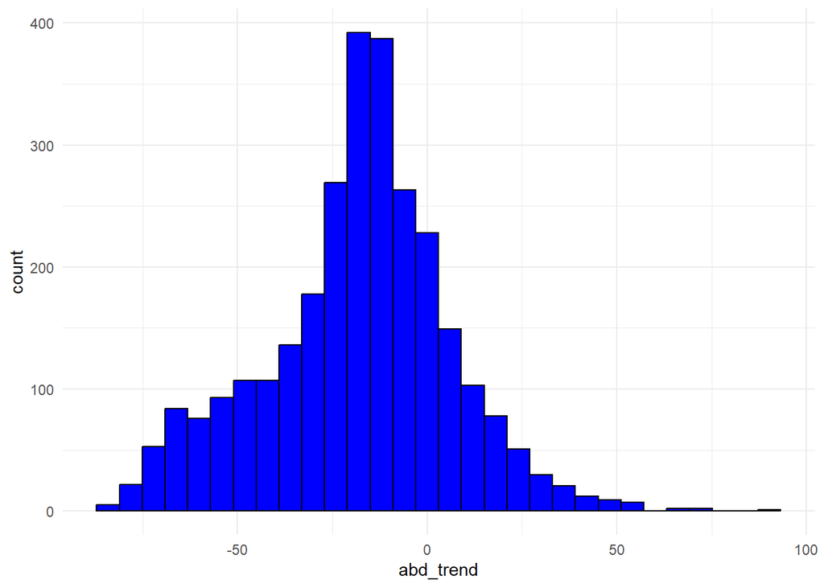

[figure not shown]

## Periphery

Mapping of trend estimates with red points identified as “core”breeding areas as defined by Morans I.

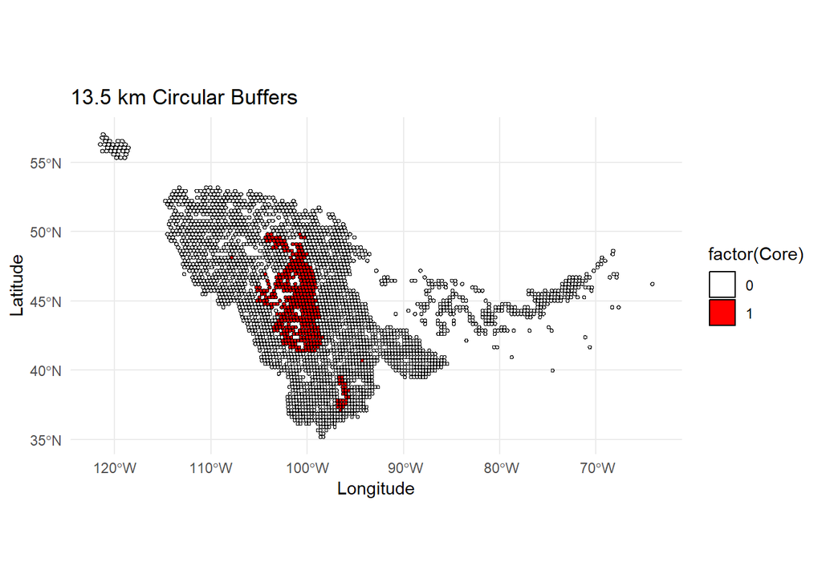

# Predictor relationships

Correlation matrix before aggregating predictors.

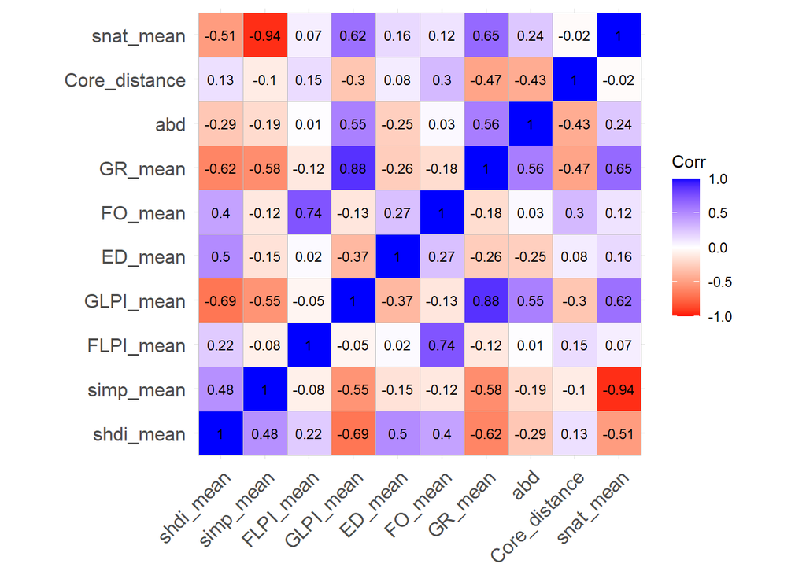

I still need to determine a pearsons correlation coefficient threshold to report. Some literature has used 0.7 and I will go with that for now. I still need to develop a better backing for this and if this is something I will continue to use going forward…

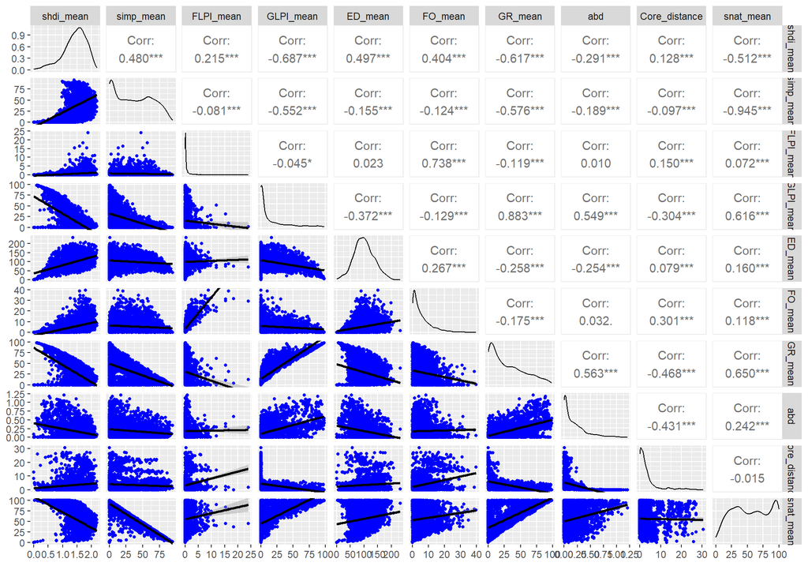

## Shannon Diversity Index

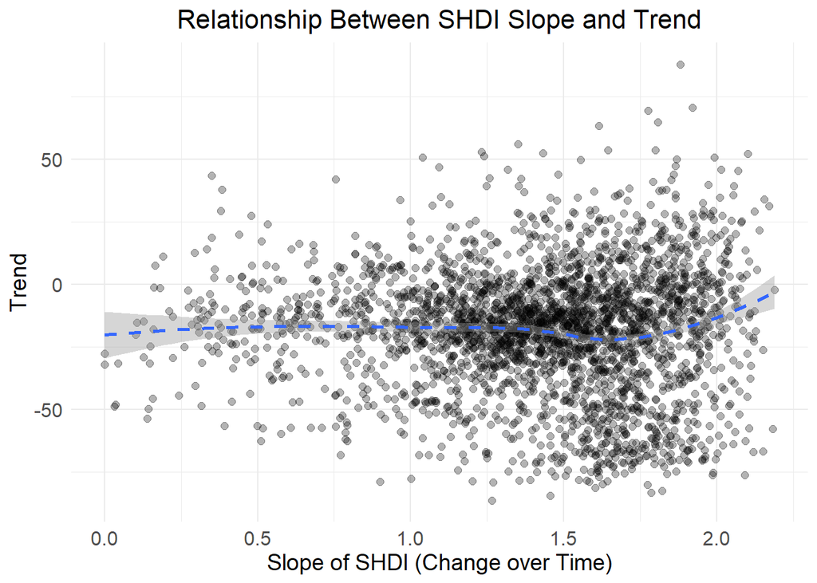

## Landscape Simplification

plot simplification slope against trend

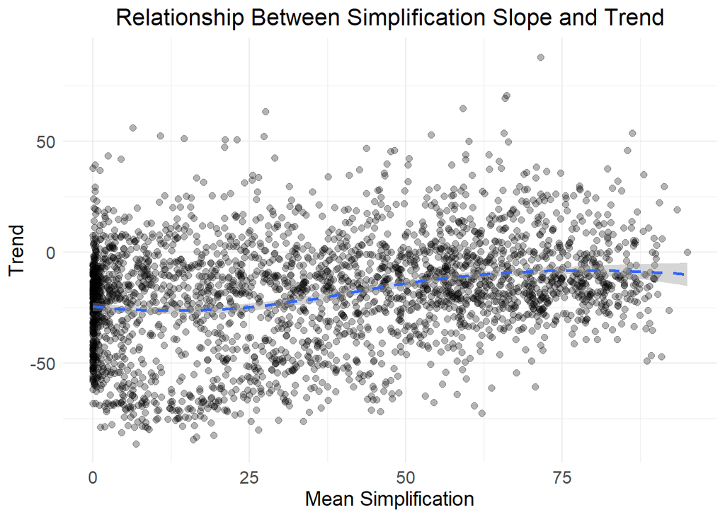

```r
SI_cube <- glm(abd_trend ~ simp_mean + I(simp_mean^2) + I(simp_mean^3), data = NA_model)
summary(SI_cube)
```

```
##
## Call:
## glm(formula = abd_trend ~ simp_mean + I(simp_mean^2) + I(simp_mean^3),
##     data = NA_model)
##
## Coefficients:
##                  Estimate Std. Error t value Pr(>|t|)
## (Intercept)    -2.430e+01  1.010e+00 -24.048  < 2e-16 ***
## simp_mean      -4.305e-01  1.283e-01  -3.355 0.000803 ***
## I(simp_mean^2)  2.046e-02  3.798e-03   5.387 7.73e-08 ***
## I(simp_mean^3) -1.563e-04  3.006e-05  -5.199 2.14e-07 ***
## ---
## Signif. codes:  0 '***' 0.001 '**' 0.01 '*' 0.05 '.' 0.1 ' ' 1
##
## (Dispersion parameter for gaussian family taken to be 548.6872)
##
##     Null deviance: 1721589  on 2864  degrees of freedom
## Residual deviance: 1569794  on 2861  degrees of freedom
## AIC: 26208
##
## Number of Fisher Scoring iterations: 2
```

```r
SI_lin <- glm(abd_trend ~ simp_mean, data = NA_model)
summary(SI_lin)
```

```
##
## Call:
## glm(formula = abd_trend ~ simp_mean, data = NA_model)
##
## Coefficients:
##             Estimate Std. Error t value Pr(>|t|)
## (Intercept) -27.5406     0.7293  -37.76   <2e-16 ***
## simp_mean     0.2504     0.0160   15.65   <2e-16 ***
## ---
## Signif. codes:  0 '***' 0.001 '**' 0.01 '*' 0.05 '.' 0.1 ' ' 1
##
## (Dispersion parameter for gaussian family taken to be 553.9208)
##
##     Null deviance: 1721589  on 2864  degrees of freedom
## Residual deviance: 1585875  on 2863  degrees of freedom
## AIC: 26233
##
## Number of Fisher Scoring iterations: 2
```

```r
AIC(SI_cube, SI_lin)
```

```
##         df      AIC
## SI_cube  5 26207.58
## SI_lin   3 26232.78
```

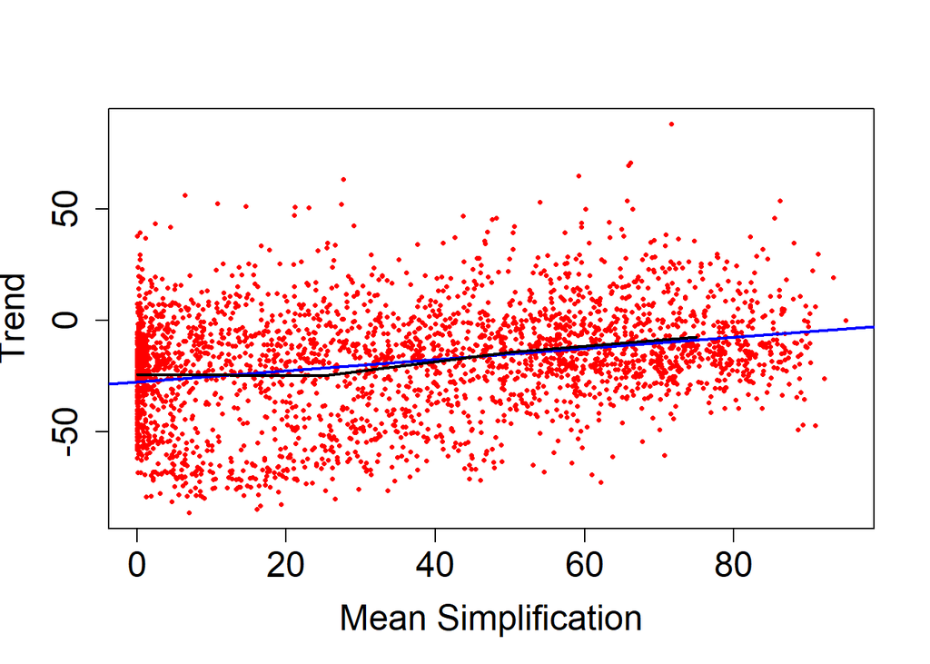

## LPI Grassland

Plot trend ~ slope and trend ~ Mean

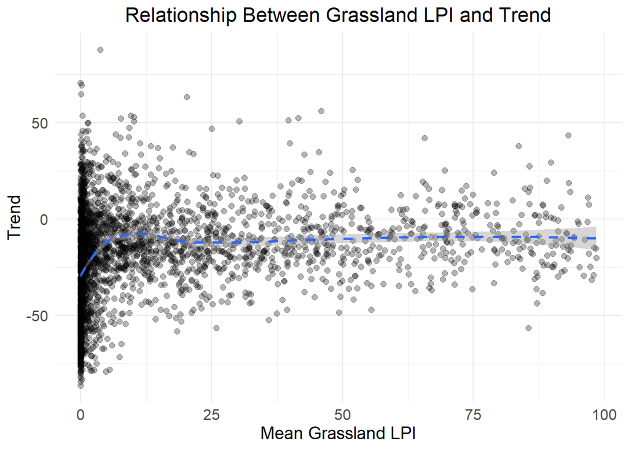

## LPI Forage

Plot trend ~ slope and trend ~ Mean

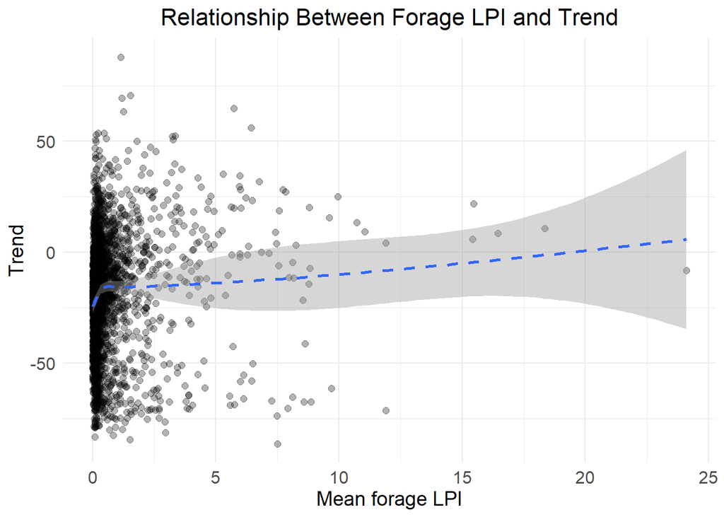

## Edge Density

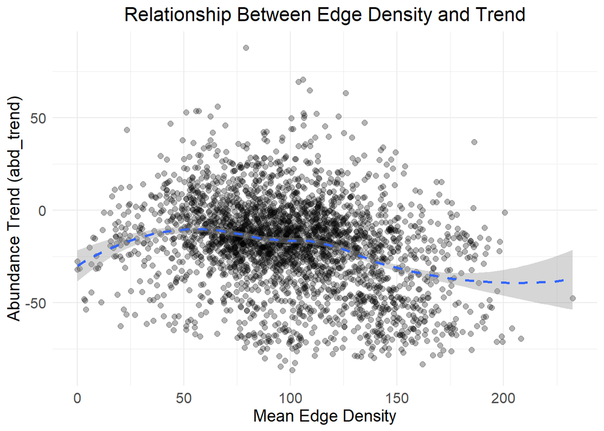

```r
ED_quad <- glm(abd_trend ~ ED_mean + I(ED_mean^2), data = NA_model)
summary(ED_quad)
```

```
##
## Call:
## glm(formula = abd_trend ~ ED_mean + I(ED_mean^2), data = NA_model)
##
## Coefficients:
##                Estimate Std. Error t value Pr(>|t|)
## (Intercept)  -1.540e+01  2.587e+00  -5.954 2.94e-09 ***
## ED_mean       1.652e-01  5.131e-02   3.219   0.0013 **
## I(ED_mean^2) -1.728e-03  2.422e-04  -7.133 1.24e-12 ***
## ---
## Signif. codes:  0 '***' 0.001 '**' 0.01 '*' 0.05 '.' 0.1 ' ' 1
##
## (Dispersion parameter for gaussian family taken to be 544.2115)
##
##     Null deviance: 1721589  on 2864  degrees of freedom
## Residual deviance: 1557533  on 2862  degrees of freedom
## AIC: 26183
##
## Number of Fisher Scoring iterations: 2
```

```r
ED_lin <- glm(abd_trend ~ ED_mean , data = NA_model)
summary(ED_lin)
```

```
##
## Call:
## glm(formula = abd_trend ~ ED_mean, data = NA_model)
##
## Coefficients:
##             Estimate Std. Error t value Pr(>|t|)
## (Intercept)  0.63164    1.29196   0.489    0.625
## ED_mean     -0.19062    0.01215 -15.693   <2e-16 ***
## ---
## Signif. codes:  0 '***' 0.001 '**' 0.01 '*' 0.05 '.' 0.1 ' ' 1
##
## (Dispersion parameter for gaussian family taken to be 553.694)
##
##     Null deviance: 1721589  on 2864  degrees of freedom
## Residual deviance: 1585226  on 2863  degrees of freedom
## AIC: 26232
##
## Number of Fisher Scoring iterations: 2
```

```r
AIC(ED_quad, ED_lin)
```

```
##         df      AIC
## ED_quad  4 26183.12
## ED_lin   3 26231.61
```

Plot of linear and quad model for Mean edge density.

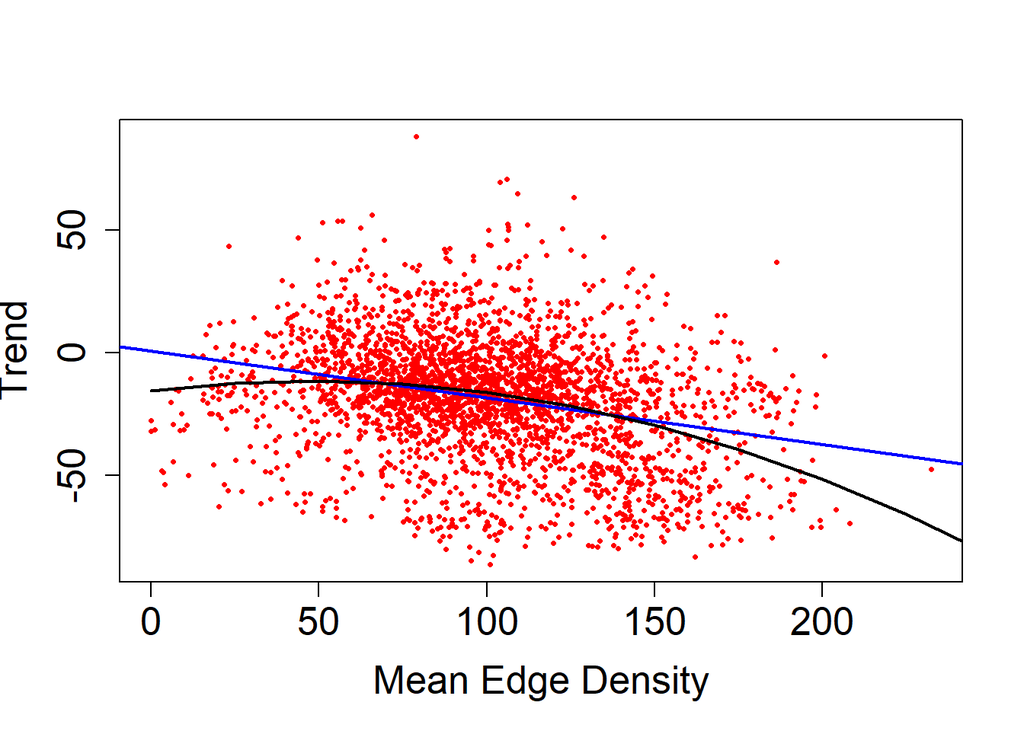

### Periphery

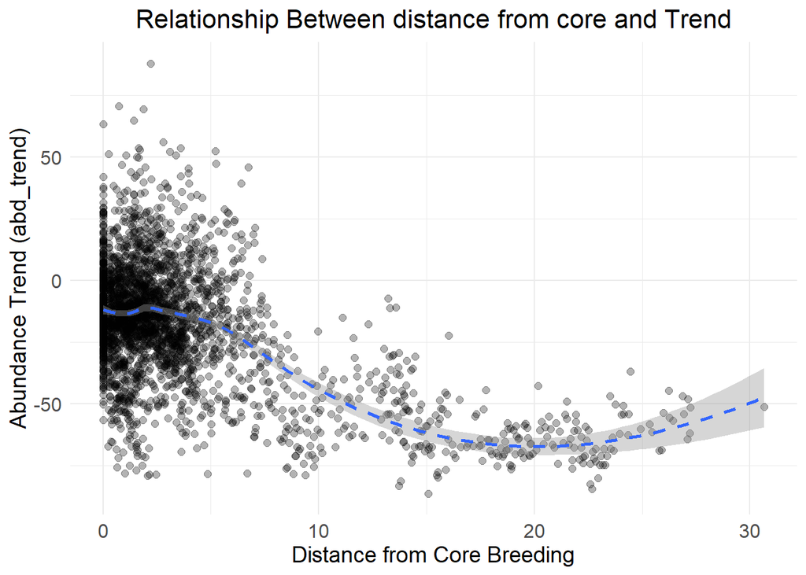

# Model Runs

## Null model

```r
null_model <- glm(abd_trend ~ 1, data = NA_model)
```

## Global Models

Removed both LPI metrics for now due to high correlation with many variables.

### Linear Models

LM 1

```r
lm_global <- lm(abd_trend ~ FO_mean + GR_mean +  shdi_mean  + simp_mean + simp_mean*shdi_mean + abd + srd_id + Core_distance, data = NA_model)
summary(lm_global)
```

```
##
## Call:
## lm(formula = abd_trend ~ FO_mean + GR_mean + shdi_mean + simp_mean +
##     simp_mean * shdi_mean + abd + srd_id + Core_distance, data = NA_model)
##
## Residuals:
##     Min      1Q  Median      3Q     Max
## -60.779 -10.518  -0.690   9.318  83.769
##
## Coefficients:
##                       Estimate Std. Error t value Pr(>|t|)
## (Intercept)          8.043e+01  4.484e+00  17.939  < 2e-16 ***
## FO_mean              4.537e-01  6.957e-02   6.521 8.24e-11 ***
## GR_mean              4.331e-01  2.405e-02  18.007  < 2e-16 ***
## shdi_mean           -1.044e+01  1.483e+00  -7.043 2.35e-12 ***
## simp_mean            5.755e-01  6.116e-02   9.409  < 2e-16 ***
## abd                 -1.452e+01  1.959e+00  -7.410 1.65e-13 ***
## srd_id              -3.846e-04  1.455e-05 -26.433  < 2e-16 ***
## Core_distance       -1.912e+00  8.857e-02 -21.581  < 2e-16 ***
## shdi_mean:simp_mean -3.525e-02  4.125e-02  -0.855    0.393
## ---
## Signif. codes:  0 '***' 0.001 '**' 0.01 '*' 0.05 '.' 0.1 ' ' 1
##
## Residual standard error: 16.8 on 2856 degrees of freedom
## Multiple R-squared:  0.5317, Adjusted R-squared:  0.5304
## F-statistic: 405.4 on 8 and 2856 DF,  p-value: < 2.2e-16
```

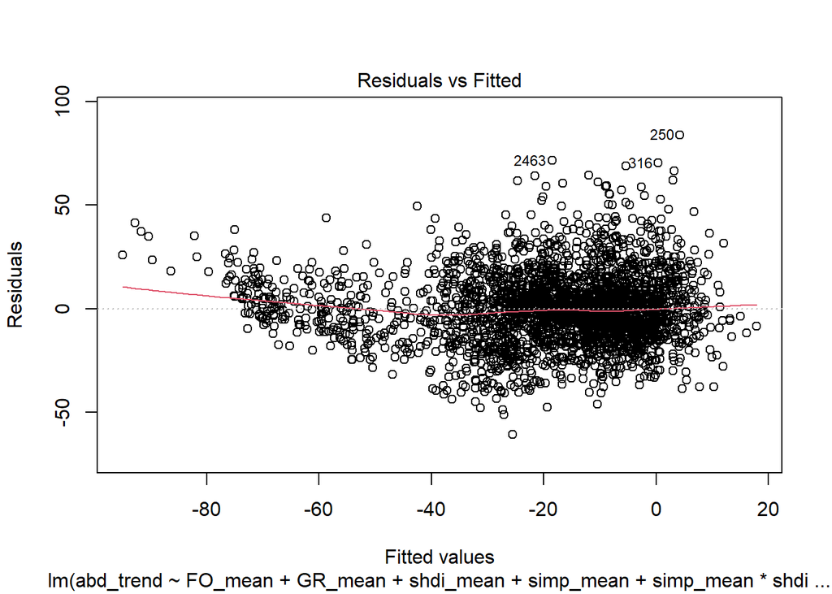

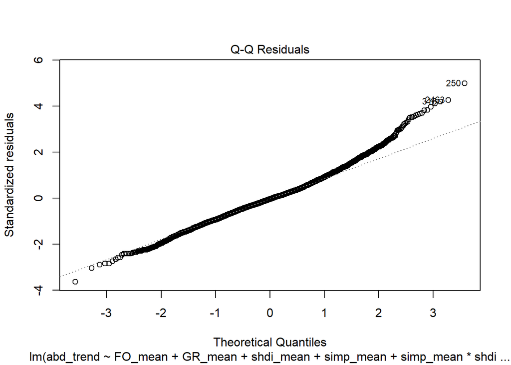

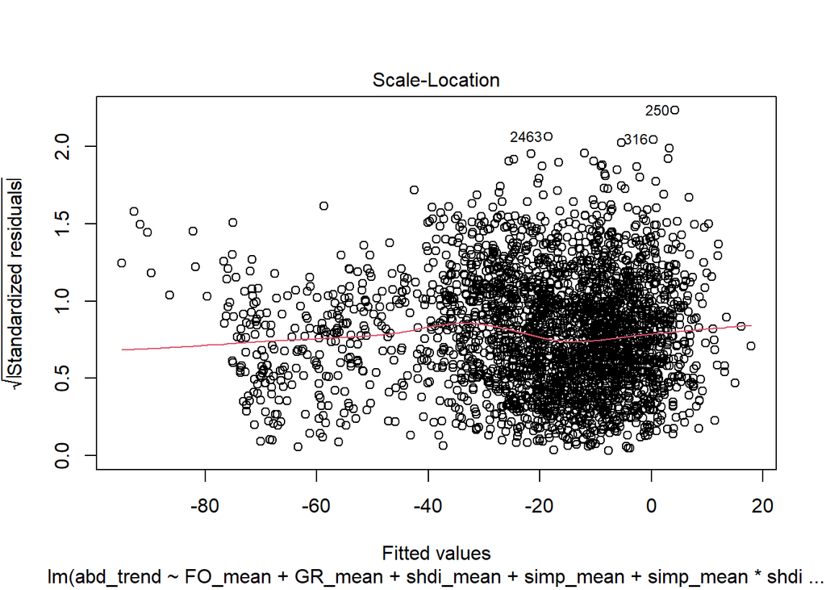

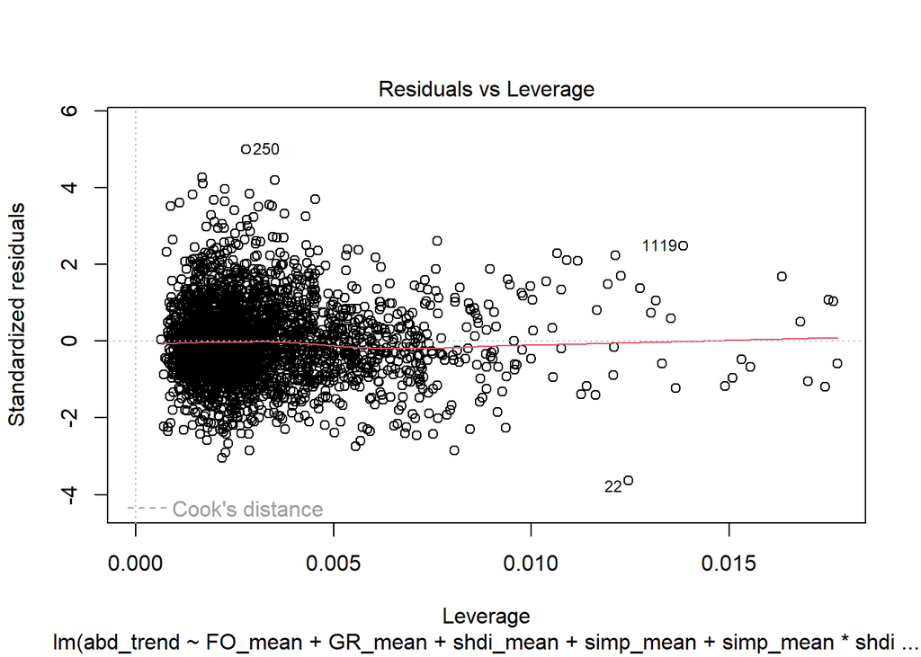

```r
plot(lm_global)
```

```r
vif(lm_global)
```

```
## there are higher-order terms (interactions) in this model
## consider setting type = 'predictor'; see ?vif
```

```
##             FO_mean             GR_mean           shdi_mean           simp_mean
##            1.709780            4.030852            3.580268           28.673103
##                 abd              srd_id       Core_distance shdi_mean:simp_mean
##            1.798956            1.635015            1.964541           33.470963
```

LM2

```r
lm_global2 <- lm(abd_trend ~  GR_mean +  shdi_mean  + simp_mean + abd + srd_id + Core_distance, data = NA_model)
summary(lm_global2)
```

```
##
## Call:
## lm(formula = abd_trend ~ GR_mean + shdi_mean + simp_mean + abd +
##     srd_id + Core_distance, data = NA_model)
##
## Residuals:
##     Min      1Q  Median      3Q     Max
## -51.024 -10.830  -0.893   9.211  82.877
##
## Coefficients:
##                 Estimate Std. Error t value Pr(>|t|)
## (Intercept)    8.154e+01  4.455e+00  18.304  < 2e-16 ***
## GR_mean        4.369e-01  2.414e-02  18.100  < 2e-16 ***
## shdi_mean     -7.490e+00  1.074e+00  -6.976 3.76e-12 ***
## simp_mean      4.975e-01  1.707e-02  29.137  < 2e-16 ***
## abd           -1.169e+01  1.924e+00  -6.076 1.39e-09 ***
## srd_id        -3.959e-04  1.308e-05 -30.280  < 2e-16 ***
## Core_distance -1.743e+00  8.555e-02 -20.378  < 2e-16 ***
## ---
## Signif. codes:  0 '***' 0.001 '**' 0.01 '*' 0.05 '.' 0.1 ' ' 1
##
## Residual standard error: 16.93 on 2858 degrees of freedom
## Multiple R-squared:  0.5244, Adjusted R-squared:  0.5234
## F-statistic: 525.2 on 6 and 2858 DF,  p-value: < 2.2e-16
```

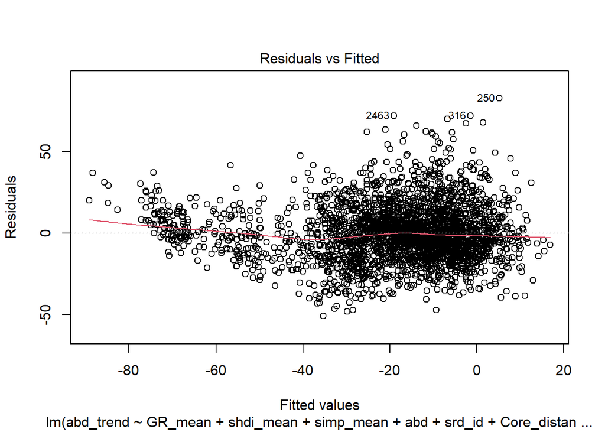

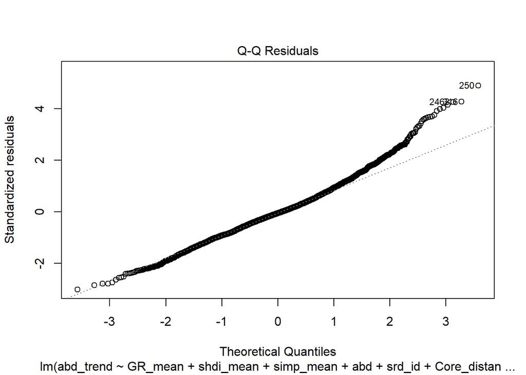

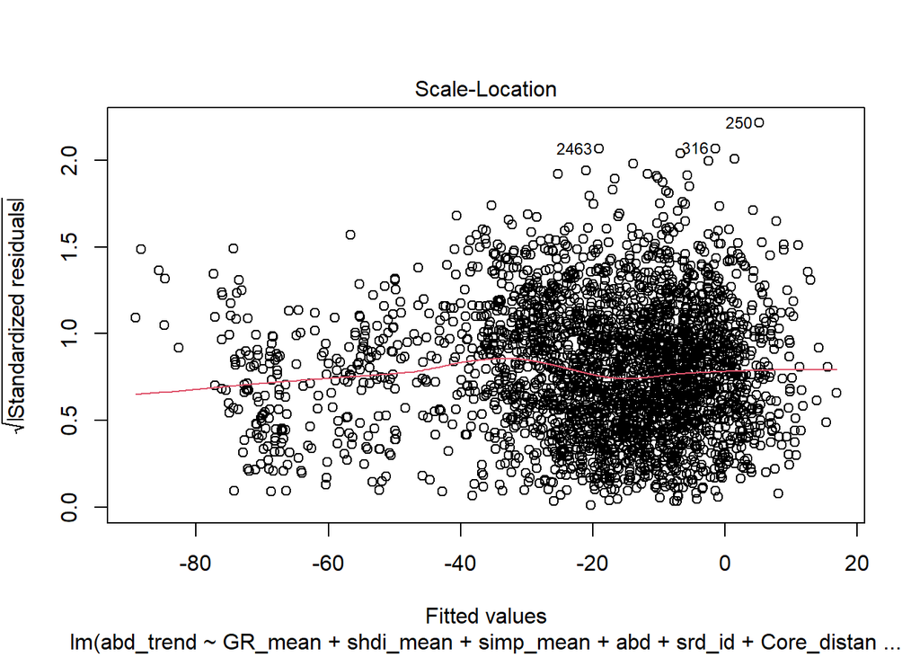

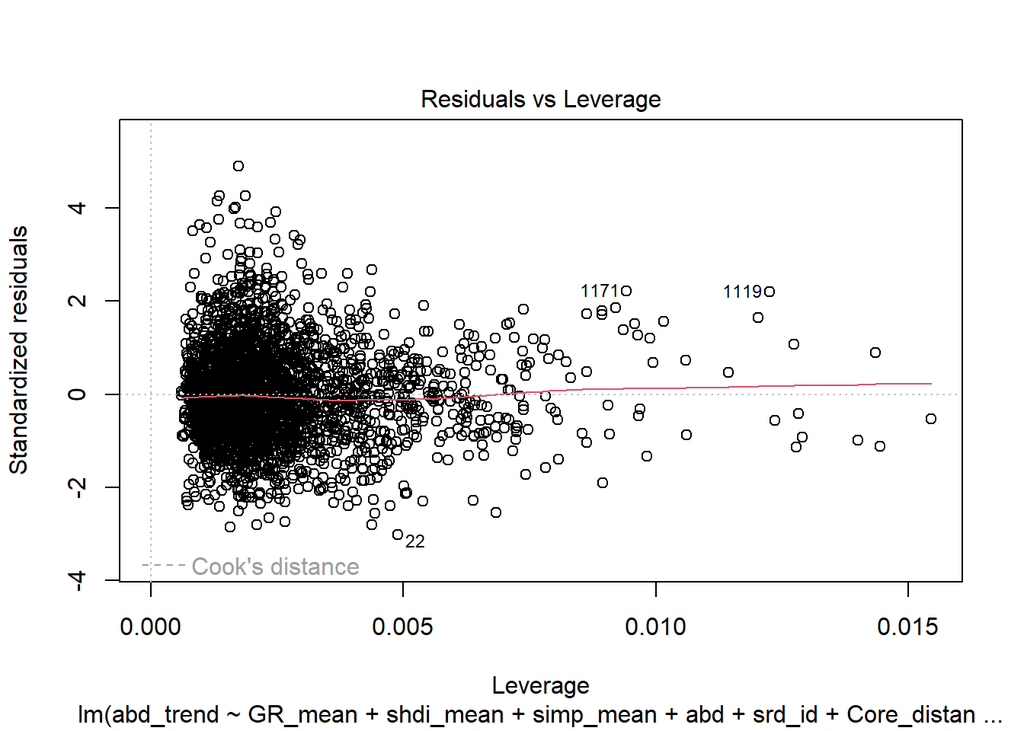

```r
plot(lm_global2)
```

```r
vif(lm_global2)
```

```
##       GR_mean     shdi_mean     simp_mean           abd        srd_id
##      4.000715      1.849814      2.201736      1.710075      1.300667
## Core_distance
##      1.805647
```

### General Linear Models

glm 1

```r
glm_global <- glm(abd_trend ~ FO_mean + GR_mean + ED_mean +  shdi_mean + simp_mean + abd + simp_mean*shdi_mean + srd_id + Core_distance, family = "gaussian", data = NA_model)
summary(glm_global)
```

```
##
## Call:
## glm(formula = abd_trend ~ FO_mean + GR_mean + ED_mean + shdi_mean +
##     simp_mean + abd + simp_mean * shdi_mean + srd_id + Core_distance,
##     family = "gaussian", data = NA_model)
##
## Coefficients:
##                       Estimate Std. Error t value Pr(>|t|)
## (Intercept)          8.025e+01  4.468e+00  17.963  < 2e-16 ***
## FO_mean              4.438e-01  6.935e-02   6.398 1.83e-10 ***
## GR_mean              3.987e-01  2.508e-02  15.893  < 2e-16 ***
## ED_mean             -6.052e-02  1.300e-02  -4.655 3.39e-06 ***
## shdi_mean           -6.224e+00  1.733e+00  -3.591 0.000335 ***
## simp_mean            5.379e-01  6.147e-02   8.750  < 2e-16 ***
## abd                 -1.513e+01  1.956e+00  -7.736 1.42e-14 ***
## srd_id              -3.698e-04  1.485e-05 -24.902  < 2e-16 ***
## Core_distance       -2.034e+00  9.207e-02 -22.088  < 2e-16 ***
## shdi_mean:simp_mean -5.246e-02  4.127e-02  -1.271 0.203809
## ---
## Signif. codes:  0 '***' 0.001 '**' 0.01 '*' 0.05 '.' 0.1 ' ' 1
##
## (Dispersion parameter for gaussian family taken to be 280.2443)
##
##     Null deviance: 1721589  on 2864  degrees of freedom
## Residual deviance:  800097  on 2855  degrees of freedom
## AIC: 24289
##
## Number of Fisher Scoring iterations: 2
```

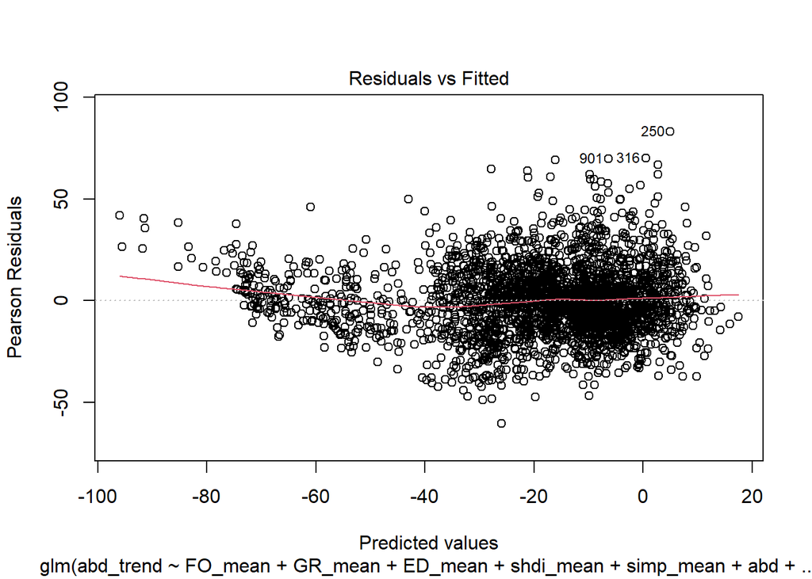

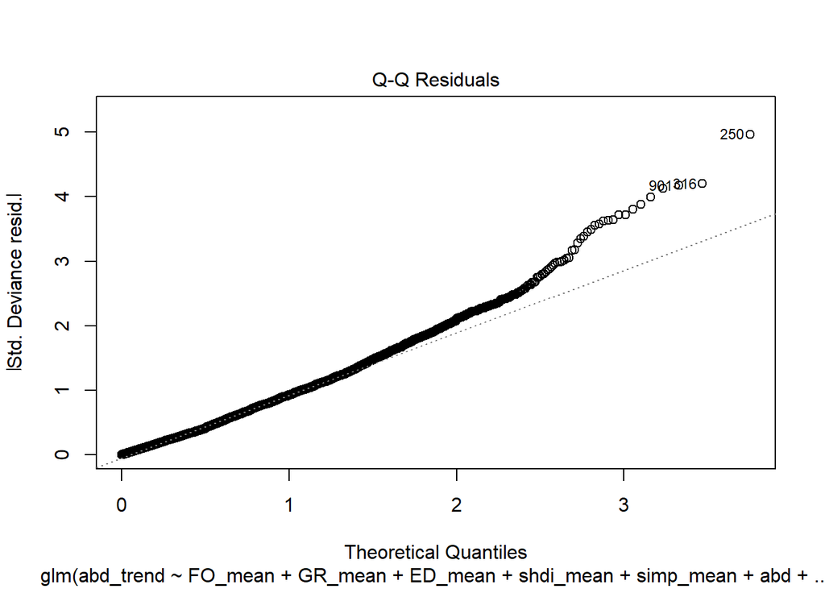

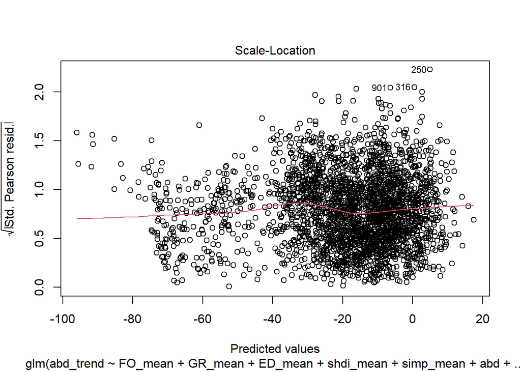

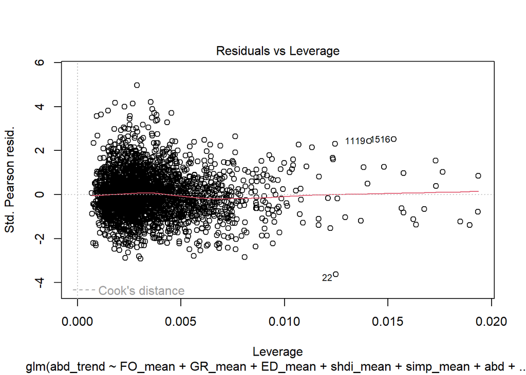

```r
plot(glm_global)
```

```r
vif(glm_global)
```

```
## there are higher-order terms (interactions) in this model
## consider setting type = 'predictor'; see ?vif
```

```
##             FO_mean             GR_mean             ED_mean           shdi_mean
##            1.711392            4.415516            2.264271            4.927368
##           simp_mean                 abd              srd_id       Core_distance
##           29.176958            1.807261            1.714620            2.138071
## shdi_mean:simp_mean
##           33.741688
```

```r
glm_global2 <- glm(abd_trend ~ FO_mean + GR_mean + ED_mean +  shdi_mean + abd + srd_id + Core_distance, family = "gaussian", data = NA_model)
summary(glm_global2)
```

```
##
## Call:
## glm(formula = abd_trend ~ FO_mean + GR_mean + ED_mean + shdi_mean +
##     abd + srd_id + Core_distance, family = "gaussian", data = NA_model)
##
## Coefficients:
##                 Estimate Std. Error t value Pr(>|t|)
## (Intercept)    7.807e+01  4.749e+00  16.437  < 2e-16 ***
## FO_mean        1.515e-01  7.270e-02   2.084  0.03728 *
## GR_mean        6.788e-02  2.118e-02   3.205  0.00137 **
## ED_mean       -2.259e-01  1.108e-02 -20.392  < 2e-16 ***
## shdi_mean      8.097e+00  1.354e+00   5.982 2.49e-09 ***
## abd           -9.983e+00  2.088e+00  -4.781 1.83e-06 ***
## srd_id        -2.692e-04  1.395e-05 -19.303  < 2e-16 ***
## Core_distance -2.871e+00  8.904e-02 -32.244  < 2e-16 ***
## ---
## Signif. codes:  0 '***' 0.001 '**' 0.01 '*' 0.05 '.' 0.1 ' ' 1
##
## (Dispersion parameter for gaussian family taken to be 324.4547)
##
##     Null deviance: 1721589  on 2864  degrees of freedom
## Residual deviance:  926967  on 2857  degrees of freedom
## AIC: 24706
##
## Number of Fisher Scoring iterations: 2
```

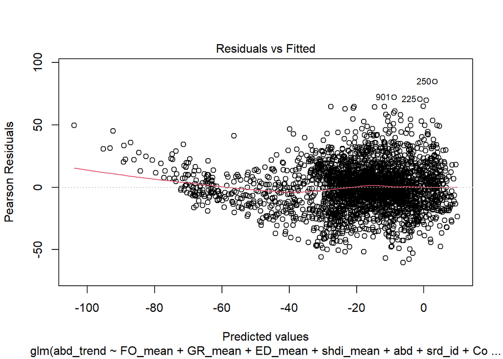

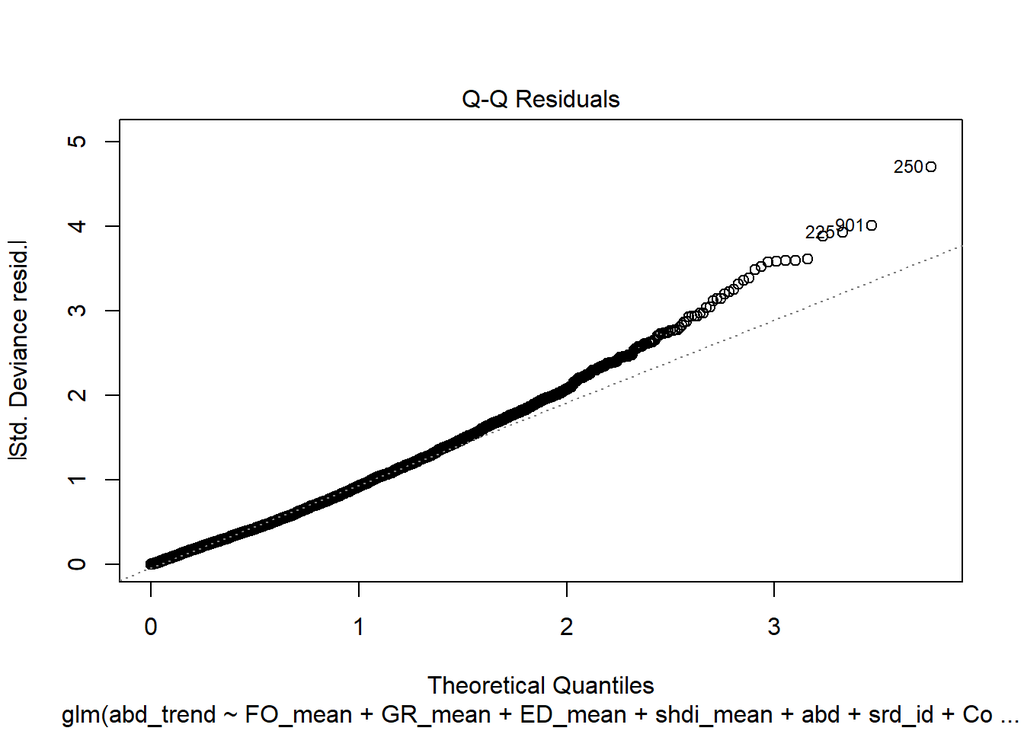

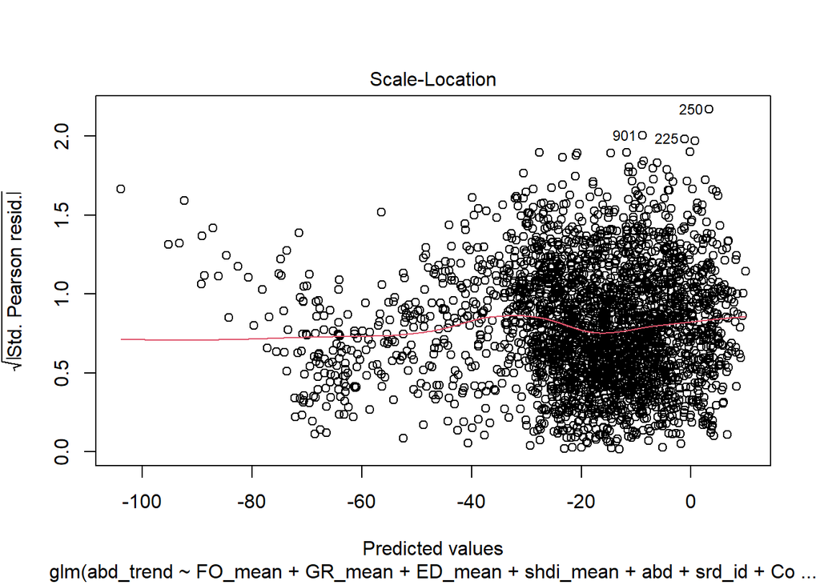

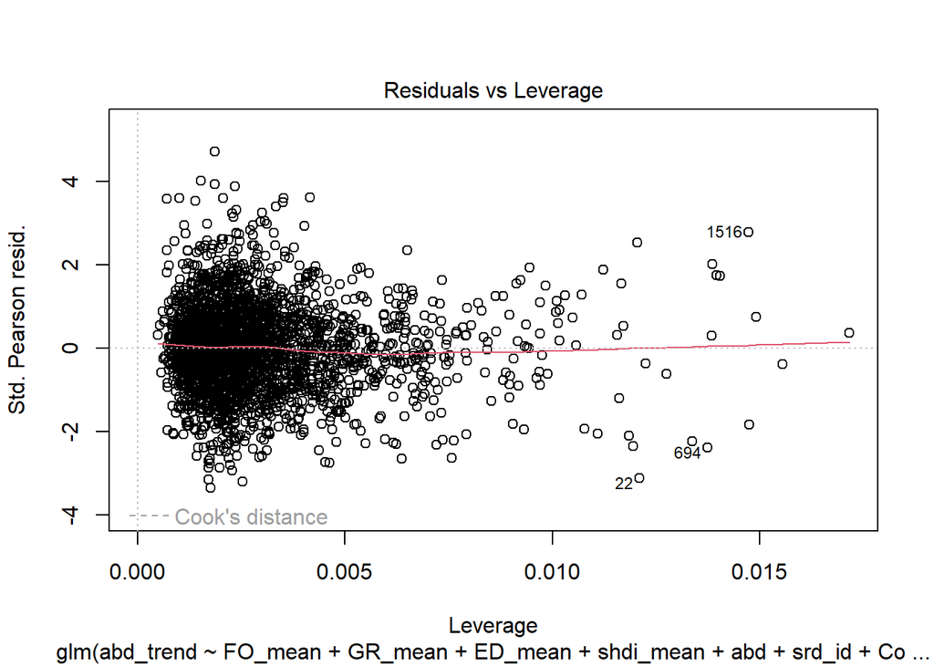

```r
plot(glm_global2)
```

```r
vif(glm_global2)
```

```
##       FO_mean       GR_mean       ED_mean     shdi_mean           abd
##      1.624226      2.718769      1.419563      2.596336      1.778298
##        srd_id Core_distance
##      1.306894      1.727341
```

### GLM Polynomial models

polynomial global

```r
poly_global <- glm(abd_trend ~ FO_mean + GR_mean + ED_mean + I(ED_mean^2) + shdi_mean + simp_mean + I(simp_mean^2) + I(simp_mean^3) + abd + srd_id + shdi_mean*simp_mean + Core_distance , data = NA_model)
summary(poly_global)
```

```
##
## Call:
## glm(formula = abd_trend ~ FO_mean + GR_mean + ED_mean + I(ED_mean^2) +
##     shdi_mean + simp_mean + I(simp_mean^2) + I(simp_mean^3) +
##     abd + srd_id + shdi_mean * simp_mean + Core_distance, data = NA_model)
##
## Coefficients:
##                       Estimate Std. Error t value Pr(>|t|)
## (Intercept)          6.901e+01  5.328e+00  12.953  < 2e-16 ***
## FO_mean              4.852e-01  6.900e-02   7.033 2.52e-12 ***
## GR_mean              4.751e-01  2.694e-02  17.638  < 2e-16 ***
## ED_mean             -1.715e-02  4.498e-02  -0.381   0.7030
## I(ED_mean^2)        -3.650e-04  1.961e-04  -1.861   0.0628 .
## shdi_mean            6.004e+00  2.592e+00   2.316   0.0206 *
## simp_mean           -2.763e-01  1.236e-01  -2.235   0.0255 *
## I(simp_mean^2)       3.521e-02  3.872e-03   9.095  < 2e-16 ***
## I(simp_mean^3)      -2.663e-04  2.903e-05  -9.175  < 2e-16 ***
## abd                 -1.450e+01  1.930e+00  -7.514 7.66e-14 ***
## srd_id              -3.747e-04  1.582e-05 -23.681  < 2e-16 ***
## Core_distance       -1.918e+00  9.149e-02 -20.959  < 2e-16 ***
## shdi_mean:simp_mean -3.292e-01  5.206e-02  -6.324 2.94e-10 ***
## ---
## Signif. codes:  0 '***' 0.001 '**' 0.01 '*' 0.05 '.' 0.1 ' ' 1
##
## (Dispersion parameter for gaussian family taken to be 271.4956)
##
##     Null deviance: 1721589  on 2864  degrees of freedom
## Residual deviance:  774305  on 2852  degrees of freedom
## AIC: 24201
##
## Number of Fisher Scoring iterations: 2
```

```r
poly_global2 <- glm(abd_trend ~ FO_mean + GR_mean +  shdi_mean + simp_mean + I(simp_mean^2) + I(simp_mean^3) + abd + srd_id + shdi_mean*simp_mean +  Core_distance , data = NA_model)
summary(poly_global2)
```

```
##
## Call:
## glm(formula = abd_trend ~ FO_mean + GR_mean + shdi_mean + simp_mean +
##     I(simp_mean^2) + I(simp_mean^3) + abd + srd_id + shdi_mean *
##     simp_mean + Core_distance, data = NA_model)
##
## Coefficients:
##                       Estimate Std. Error t value Pr(>|t|)
## (Intercept)          7.859e+01  5.109e+00  15.382  < 2e-16 ***
## FO_mean              4.771e-01  6.952e-02   6.863 8.22e-12 ***
## GR_mean              4.925e-01  2.706e-02  18.201  < 2e-16 ***
## shdi_mean           -3.714e+00  2.005e+00  -1.853    0.064 .
## simp_mean            6.850e-02  1.141e-01   0.600    0.548
## I(simp_mean^2)       2.779e-02  3.671e-03   7.572 4.94e-14 ***
## I(simp_mean^3)      -2.223e-04  2.793e-05  -7.959 2.47e-15 ***
## abd                 -1.373e+01  1.940e+00  -7.078 1.83e-12 ***
## srd_id              -4.060e-04  1.529e-05 -26.547  < 2e-16 ***
## Core_distance       -1.785e+00  8.963e-02 -19.913  < 2e-16 ***
## shdi_mean:simp_mean -2.745e-01  5.048e-02  -5.437 5.87e-08 ***
## ---
## Signif. codes:  0 '***' 0.001 '**' 0.01 '*' 0.05 '.' 0.1 ' ' 1
##
## (Dispersion parameter for gaussian family taken to be 276.1988)
##
##     Null deviance: 1721589  on 2864  degrees of freedom
## Residual deviance:  788271  on 2854  degrees of freedom
## AIC: 24248
##
## Number of Fisher Scoring iterations: 2
```

```r
poly_global3 <- glm(abd_trend ~ FO_mean + GR_mean  + simp_mean + I(simp_mean^2) + I(simp_mean^3) + abd + srd_id + shdi_mean*simp_mean +  Core_distance , data = NA_model)
summary(poly_global3)
```

```
##
## Call:
## glm(formula = abd_trend ~ FO_mean + GR_mean + simp_mean + I(simp_mean^2) +
##     I(simp_mean^3) + abd + srd_id + shdi_mean * simp_mean + Core_distance,
##     data = NA_model)
##
## Coefficients:
##                       Estimate Std. Error t value Pr(>|t|)
## (Intercept)          7.859e+01  5.109e+00  15.382  < 2e-16 ***
## FO_mean              4.771e-01  6.952e-02   6.863 8.22e-12 ***
## GR_mean              4.925e-01  2.706e-02  18.201  < 2e-16 ***
## simp_mean            6.850e-02  1.141e-01   0.600    0.548
## I(simp_mean^2)       2.779e-02  3.671e-03   7.572 4.94e-14 ***
## I(simp_mean^3)      -2.223e-04  2.793e-05  -7.959 2.47e-15 ***
## abd                 -1.373e+01  1.940e+00  -7.078 1.83e-12 ***
## srd_id              -4.060e-04  1.529e-05 -26.547  < 2e-16 ***
## shdi_mean           -3.714e+00  2.005e+00  -1.853    0.064 .
## Core_distance       -1.785e+00  8.963e-02 -19.913  < 2e-16 ***
## simp_mean:shdi_mean -2.745e-01  5.048e-02  -5.437 5.87e-08 ***
## ---
## Signif. codes:  0 '***' 0.001 '**' 0.01 '*' 0.05 '.' 0.1 ' ' 1
##
## (Dispersion parameter for gaussian family taken to be 276.1988)
##
##     Null deviance: 1721589  on 2864  degrees of freedom
## Residual deviance:  788271  on 2854  degrees of freedom
## AIC: 24248
##
## Number of Fisher Scoring iterations: 2
```